# STAT 420: Homework 2

## Exercise 2 (Writing Functions)

This exercise is a continuation of Exercise 1.

**(a)** Write a function called `get_sd_est` that calculates an estimate of $\sigma$ in one of two ways depending on input to the function. The function should take two arguments as input:

- `model_resid` - A vector of residual values from a fitted model.
- `mle` - A logical (`TRUE` / `FALSE`) variable which defaults to `FALSE`.

The function should return a single value:

- $s_e$ if `mle` is set to `FALSE`.
- $\hat{\sigma}$ if `mle` is set to `TRUE`.

```r
model_resid = resid(faithful_model)
get_sd_est = function(model_resid, mle){
  if(mle == FALSE){
    e = model_resid
    n     = length(e)
    s2_e  = sum(e^2) / (n - 2)
    s2_e
    s_e = sqrt(s2_e) #Taking the square root, computes the standard deviation of the residuals, also                     known as residual standard error.
    s_e
  }else{
    e = model_resid
    n     = length(e)
    o2_e  = sum(e^2) / (n )
    o2_e
    o_e = sqrt(o2_e)
    o_e
  }
}
```

**(b)** Run the function `get_sd_est` on the residuals from the model in Exercise 1, with `mle` set to `FALSE`.

```r
get_sd_est(model_resid, FALSE)
```

```
## [1] 0.4965129
```

**(c)** Run the function `get_sd_est` on the residuals from the model in Exercise 1, with `mle` set to `TRUE`.

```r
get_sd_est(model_resid, TRUE)
```

```
## [1] 0.4946842
```

**(d)** To check your work, output `summary(faithful_model)$sigma`. It should match at least one of **(b)** or **(c)**.

```r
summary(faithful_model)$sigma
```

```
## [1] 0.4965129
```

## Exercise 3 (SLR Without Intercept)

Sometimes it can be reasonable to assume that $\beta_0$ should be 0. That is, the line should pass through the point $(0, 0)$. For example, if a car is traveling 0 miles per hour, its stopping distance should be 0! (Unlike what we saw in the book.)

We can simply define a model without an intercept,

$$Y_i = \beta x_i + \epsilon_i.$$

**(a)** [In the **Least Squares Approach** section of the text](http://daviddalpiaz.github.io/appliedstats/simple-linear-regression.html#least-squares-approach) you saw the calculus behind the derivation of the regression estimates, and then we performed the calculation for the `cars` dataset using `R`. Here you need to do, but not show the derivation for the slope only model. You should then use that derivation of $\hat{\beta}$ to write a function that performs the calculation for the estimate you derived.

In summary, use the method of least squares to derive an estimate for $\beta$ using data points $(x_i, y_i)$ for $i = 1, 2, \ldots n$. Simply put, find the value of $\beta$ to minimize the function

$$f(\beta)=\sum_{i=1}^{n}(y_{i}-\beta x_{i})^{2}.$$

Then, write a function `get_beta_no_int` that takes input:

- `x` - A predictor variable.
- `y` - A response variable.

The function should then output the $\hat{\beta}$ you derived for a given set of data.

```r
get_beta_no_int = function(x, y){
  sxy = sum(x * y)-mean(x)*mean(y)
  sxx = sum(x^2) - mean(x^2)
  beta_hat = sxy/sxx
  beta_hat
}
```

**(b)** *This question is optional and you **may** recieve a small number of bonus points for completing it.* Write your derivation in your `.Rmd` file using TeX. Or write your derivation by hand, scan or photograph your work, and insert it into the `.Rmd` as an image. See the RMarkdown documentation for working with images.

**(c)** Test your function on the `faithful` data using the waiting time as `x` and the eruption length as `y`. What is the estimate for $\beta$ for this data?

```r
get_beta_no_int(faithful$waiting,faithful$eruptions)
```

```
## [1] 0.05013905
```

**(d)** Check your work in `R`. The following syntax can be used to fit a model without an intercept:

```r
lm(faithful$eruptions ~ 0 + faithful$waiting, data = faithful)
```

```
##
## Call:
## lm(formula = faithful$eruptions ~ 0 + faithful$waiting, data = faithful)
##
## Coefficients:
## faithful$waiting
##          0.05013
```

Use this to fit a model to the `faithful` data without an intercept. Output the coefficient of the fitted model. It should match your answer to **(c)**.

## Exercise 4 (Comparing Models)

For this exercise we will use the data stored in `goalies.csv`. It contains career data for all 716 players in the history of the National Hockey League to play goaltender through the 2014-2015 season. The variables in the dataset are:

- `Player` - NHL Player Name
- `First` - First year of NHL career
- `Last` - Last year of NHL career
- `GP` - Games Played
- `GS` - Games Started
- `W` - Wins
- `L` - Losses
- `TOL` - Ties/Overtime/Shootout Losses
- `GA` - Goals Against
- `SA` - Shots Against
- `SV` - Saves
- `SV_PCT` - Save Percentage
- `GAA` - Goals Against Average
- `SO` - Shutouts
- `MIN` - Minutes
- `G` - Goals (that the player recorded, not opponents)
- `A` - Assists (that the player recorded, not opponents)
- `PTS` - Points (that the player recorded, not opponents)
- `PIM` - Penalties in Minutes

For this exercise we will define the “Root Mean Square Error” of a model as

$$RMSE = \sqrt{\frac{1}{n} \sum_{i = 1}^{n}(y_i - \hat{y}_i)^2}.$$

**(a)** Fit a model with “wins”" as the response and “minutes” as the predictor. Calculate the RMSE of this model. Also provide a scatterplot with the fitted regression line.

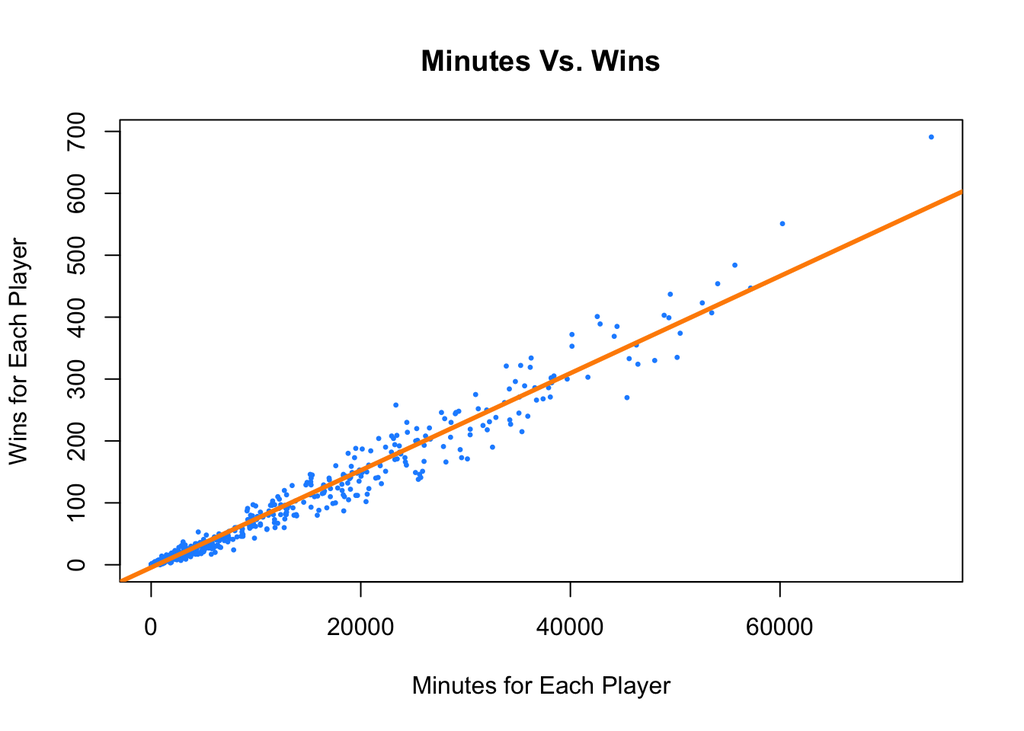

```r
goalies <- read.csv("~/Downloads/goalies.csv")

goalies_v = lm(formula = goalies$W ~ goalies$MIN, data = goalies)
resid_goalies = resid(goalies_v)
RMSE <- sqrt(mean((resid_goalies)^2))

#RMSE = 16.75758

plot(goalies$W ~ goalies$MIN, data = goalies,
      xlab = "Minutes for Each Player",
      ylab = "Wins for Each Player",
      main = "Minutes Vs. Wins",
      pch  = 20,
      cex  = 0.5,
      col  = "dodgerblue")
abline(goalies_v, lwd = 3, col = "darkorange")
```

**(b)** Fit a model with “wins”" as the response and “goals against” as the predictor. Calculate the RMSE of this model. Also provide a scatterplot with the fitted regression line.

[figure not shown]

```r
goalies <- read.csv("~/Downloads/goalies.csv")

goalies_v = lm(formula = goalies$W ~ goalies$GA, data = goalies)
resid_goalies = resid(goalies_v)
RMSE <- sqrt(mean((resid_goalies)^2))

#RSME = 31.08159

plot(goalies$W ~ goalies$GA, data = goalies,
      xlab = "Number of Wins for Each Player",
      ylab = "Number of Goals for Each Player",
      main = "Wins vs Goals",
      pch  = 20,
      cex  = 0.5,
      col  = "dodgerblue")
abline(goalies_v, lwd = 3, col = "darkorange")
```

**(c)** Fit a model with “wins”" as the response and “shutouts” as the predictors. Calculate the RMSE of this model. Also provide a scatterplot with the fitted regression line.

[figure not shown]

```r
goalies <- read.csv("~/Downloads/goalies.csv")

goalies_v = lm(formula = goalies$W ~ goalies$SO, data = goalies)
resid_goalies = resid(goalies_v)
RMSE <- sqrt(mean((resid_goalies)^2))

#RSME = 44.83837

plot(goalies$W ~ goalies$SO, data = goalies,
      xlab = "Numbers of Wins for Each Player",
      ylab = "Numbers of Shutouts for Each Player",
      main = "Wins vs Shutouts",
      pch  = 20,
      cex  = 0.5,
      col  = "dodgerblue")
abline(goalies_v, lwd = 3, col = "darkorange")
```

**(d)** Based on the previous three models, which of the three predictors used is most helpful for predicting wins? Briefly explain.

```r
#First one because the RSME was the smallest.
```